# Holtemme functional synthesis

# 1 Scope and frozen input

This report reconstructs the publication Figure 4 from the frozen v0.1.4 family-cell provenance table. The table is the scientific input; the plotting code does not rerun enrichment, semantic reduction, resolver calls, or family assignment. Target-supported, matched-background, and default-domain exploratory evidence remain separate provenance tiers.

```r
figure4_family_cells <- read.delim(figure_source, sep = "\t", check.names = FALSE, stringsAsFactors = FALSE)
figure4_family_cells |> dplyr::summarise(
  family_cells = dplyr::n(),
  displayed_cells = sum(toupper(display_in_figure) %in% c("TRUE", "T", "1")),
  target_features = sum(as.integer(n_target_supported_features)),
  matched_features = sum(as.integer(n_matched_background_hypothesis_features)),
  exploratory_features = sum(as.integer(n_default_domain_exploratory_only_features))
)
```

```
##   family_cells displayed_cells target_features matched_features
## 1          101             101             108                8
##   exploratory_features
## 1                  106
```

# 2 Figure 4: functional-response landscape

The complete reviewed construction and save logic is kept in the repository script `scripts/reconstruct_figure4_from_frozen_provenance.R`. The Rmd calls that same code path, writes the canonical PDF/PNG/SVG bundle, and leaves the publication figure embedded in this report.

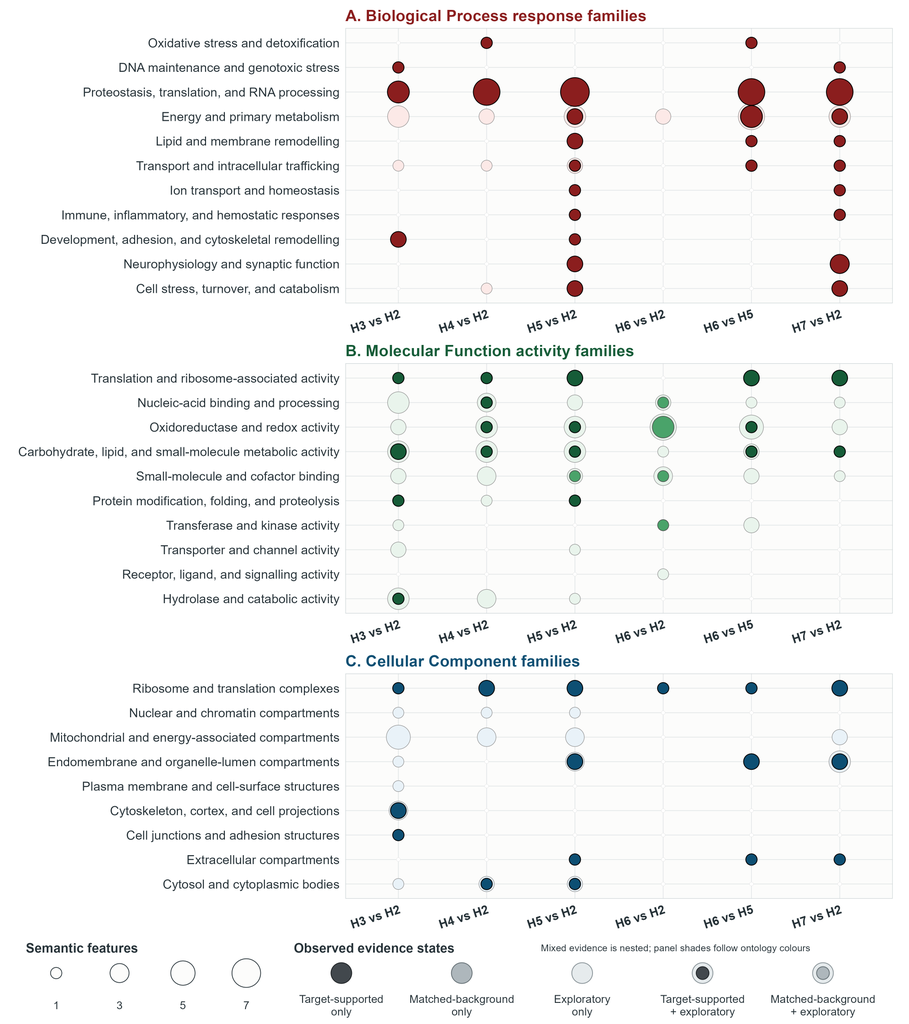

```r
figure4_script <- file.path(project_dir, "scripts", "reconstruct_figure4_from_frozen_provenance.R")
if (!file.exists(figure4_script)) stop("Figure 4 reconstruction script is missing: ", figure4_script)
status <- system2(
  file.path(R.home("bin"), "Rscript.exe"),
  args = c(figure4_script, figure_source, figure_output_dir)
)
if (!identical(status, 0L)) stop("Figure 4 reconstruction failed")
figure4_png <- file.path(figure_output_dir, "figure4_functional_response_landscape.png")
figure4_pdf <- file.path(figure_output_dir, "figure4_functional_response_landscape.pdf")
figure4_svg <- file.path(figure_output_dir, "figure4_functional_response_landscape.svg")
stopifnot(file.exists(figure4_png), file.exists(figure4_pdf), file.exists(figure4_svg))
knitr::include_graphics(figure4_png)
```

**Figure 4 legend.** Bubble area represents the number of distinct semantic features in each reviewed family cell. Fill shades distinguish functional evidence supported directly in *G. pulex*, matched-background cross-species annotation evidence, and broader exploratory annotation evidence. When more than one evidence type occurs in the same family cell, the circles are nested; the legend shows the five evidence-state combinations observed in the plotted data. Cross-species annotation evidence is used to broaden biological context and is not treated as independent validation of the *G. pulex* response.

```r
data.frame(
  source = basename(figure_source),
  pdf = basename(figure4_pdf),
  png = basename(figure4_png),
  svg = basename(figure4_svg),
  png_md5 = unname(tools::md5sum(figure4_png))
)
```

```
##                               source                                       pdf
## 1 figure4_family_cell_provenance.tsv figure4_functional_response_landscape.pdf
##                                         png
## 1 figure4_functional_response_landscape.png
##                                         svg                          png_md5
## 1 figure4_functional_response_landscape.svg 38751f4212bc68abf7fa345c39c4bd5d
```

# 3 Representative genes linked to functional-response families

```r
candidate_file <- c(
  file.path(project_dir, "DP05_functional_evidence", "publication_artifacts", "Figure_S5", "candidate_gene_display_panel.tsv"),
  file.path(release_root, "DP05_functional_evidence", "publication_artifacts", "Figure_S5", "candidate_gene_display_panel.tsv"),
  file.path(project_dir, "support", "echogo_v014_end_to_end", "s5", "candidate_gene_display_panel.tsv")
)
candidate_file <- candidate_file[file.exists(candidate_file)][1L]
candidate_mat_file <- c(
  file.path(project_dir, "DP05_functional_evidence", "publication_artifacts", "Figure_S5", "candidate_gene_expression_site_mean_row_scaled_vst.tsv"),
  file.path(release_root, "DP05_functional_evidence", "publication_artifacts", "Figure_S5", "candidate_gene_expression_site_mean_row_scaled_vst.tsv")
)
candidate_mat_file <- candidate_mat_file[file.exists(candidate_mat_file)][1L]
candidate_heatmap_file <- c(
  file.path(project_dir, "DP05_functional_evidence", "publication_artifacts", "Figure_S5", "figure5_functional_family_linked_candidate_gene_heatmap.png"),
  file.path(release_root, "DP05_functional_evidence", "publication_artifacts", "Figure_S5", "figure5_functional_family_linked_candidate_gene_heatmap.png")
)
candidate_heatmap_file <- candidate_heatmap_file[file.exists(candidate_heatmap_file)][1L]
if (is.na(candidate_file) || is.na(candidate_mat_file) || is.na(candidate_heatmap_file)) {
  cat("The frozen 16-gene S5 source is not present in this checkout. The release candidate carries the machine-readable panel and heatmap.")
} else {
  candidate_panel <- read.delim(candidate_file, sep = "\t", check.names = FALSE, stringsAsFactors = FALSE)
  candidate_mat <- read.delim(candidate_mat_file, sep = "\t", check.names = FALSE, stringsAsFactors = FALSE)
  stopifnot(nrow(candidate_panel) == 16L, nrow(candidate_mat) == 16L)
  candidate_panel <- candidate_panel[order(candidate_panel$selection_rank_global), , drop = FALSE]
  candidate_mat <- candidate_mat[match(candidate_panel$heatmap_row_label, candidate_mat$heatmap_row_label), , drop = FALSE]
  candidate_families <- unique(candidate_panel$primary_family)
  cat("The final panel contains **16 displayed genes** across **", length(candidate_families),
      " Biological Process families**, using H2-H7 site means derived from **30 individual libraries**. ",
      "All displayed rows are target-supported evidence only.\n\n", sep = "")
  cat(sprintf("<p><img src=\"%s\" alt=\"Final 16-gene S5 heatmap\" style=\"display:block; margin:auto; width:100%%;\" /></p>", base64enc::dataURI(file = candidate_heatmap_file, mime = "image/png")))
  compact_candidate_table <- candidate_panel[, c("candidate_display_label", "primary_family", "family_contrasts"), drop = FALSE]
  names(compact_candidate_table) <- c("Gene", "Functional family", "Principal linked contrast or provenance context")
  print(knitr::kable(compact_candidate_table, caption = "Final 16-gene target-supported S5 panel"))
  cat("Across the frozen H2-H7 site means, ALDOA was relatively higher at H2 and lower across H3-H5 before a modest recovery at H6-H7; MIOX peaked at H5 and remained relatively high at H6-H7; KDSR also peaked at H5 and was relatively lower at H7; FABP4 was relatively lower at H2-H4 and H6 and higher at H7; CD209 was highest at H7 and lowest at H3, with a non-monotonic pattern; and jhamt was relatively higher at H2, lower at H4, and varied non-monotonically across the remaining sites. These are descriptive site-mean VST observations within the selected panel.\\n\\n")
  cat("Colours are within-gene relative expression: red indicates relatively higher expression for a gene across sites and blue indicates relatively lower expression. Candidate selection is based on traceable target-supported functional evidence. The heatmap does not establish biomarkers, causal chemical drivers, pathway activation magnitude, or regulatory networks.")
}
```

The frozen 16-gene S5 source is not present in this checkout. The release candidate carries the machine-readable panel and heatmap.